# Dallas Housing Market Study

### Results

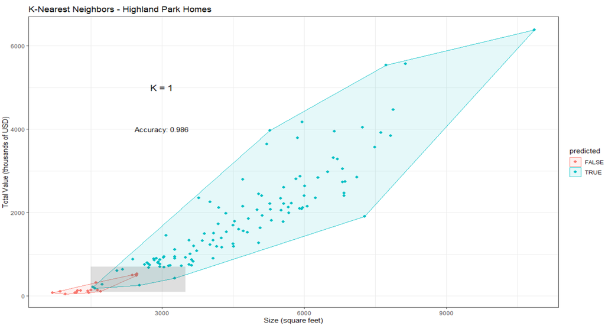

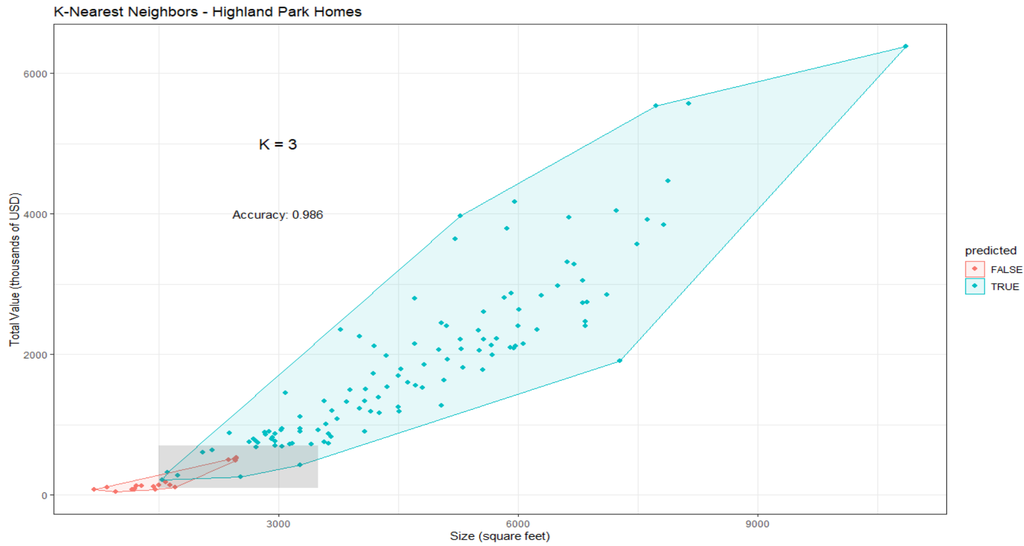

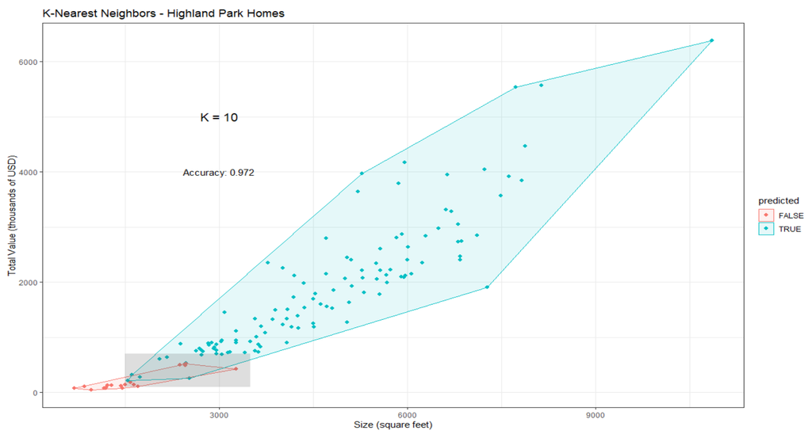

[figure not shown]

```r
# Create a dataframe to simplify charting
knnPLOT.df1 = data.frame(knnPLOTtest, predicted = knnPLOTfit1)
knnPLOT.df3 = data.frame(knnPLOTtest, predicted = knnPLOTfit3)
knnPLOT.df10 = data.frame(knnPLOTtest, predicted = knnPLOTfit10)

# First use Convex hull to determine boundary points of each cluster
knnPLOT.df1h = data.frame(x = knnPLOT.df1$TOT_MAIN_SF,
                      y = knnPLOT.df1$TOT_VAL/1000,
                      predicted = knnPLOT.df1$predicted)
knnPLOT.df3h = data.frame(x = knnPLOT.df3$TOT_MAIN_SF,
                      y = knnPLOT.df3$TOT_VAL/1000,
                      predicted = knnPLOT.df3$predicted)
knnPLOT.df10h = data.frame(x = knnPLOT.df10$TOT_MAIN_SF,
                      y = knnPLOT.df10$TOT_VAL/1000,
                      predicted = knnPLOT.df10$predicted)

find_hull1 = function(df) df[chull(df$x, df$y), ]
boundary1 = ddply(knnPLOT.df1h, .variables = "predicted", .fun = find_hull1)
find_hull3 = function(df) df[chull(df$x, df$y), ]
boundary3 = ddply(knnPLOT.df3h, .variables = "predicted", .fun = find_hull3)
find_hull10 = function(df) df[chull(df$x, df$y), ]
boundary10 = ddply(knnPLOT.df10h, .variables = "predicted", .fun = find_hull10)

# Confusion matrix for each k
knncf1<-confusionMatrix(data=knnPLOT.df1$predicted, as.factor(knnPLOT.df1$isHP), positive = 'TRUE')
knncf3<-confusionMatrix(data=knnPLOT.df3$predicted, as.factor(knnPLOT.df3$isHP), positive = 'TRUE')
knncf10<-confusionMatrix(data=knnPLOT.df10$predicted, as.factor(knnPLOT.df10$isHP), positive = 'TRUE')

# Pull out accuracy
knncf1_acc<-knncf1$overall["Accuracy"]
knncf3_acc<-knncf3$overall["Accuracy"]
knncf10_acc<-knncf10$overall["Accuracy"]

# Plot
par(mfrow=c(1,3))
ggplot(knnPLOT.df1, aes(TOT_MAIN_SF, TOT_VAL/1000, color = predicted, fill = predicted)) +
  geom_point(size = 3, pch=20) +
  geom_polygon(data = boundary1, aes(x,y), alpha = 0.10)+
  ylab("Total Value (thousands of USD)")+
  xlab("Size (square feet)")+
  ggtitle("K-Nearest Neighbors - Highland Park Homes")+
  annotate("text", x=3000, y=5000, label= "K = 1", size=5)+
  annotate("rect", xmin = 1500, xmax = 3500, ymin = 100, ymax = 700,alpha = .2)+
  annotate("text", label = paste("Accuracy:",round(knncf1_acc,3)), x=3000, y=4000)+
  theme_bw()
ggplot(knnPLOT.df3, aes(TOT_MAIN_SF, TOT_VAL/1000, color = predicted, fill = predicted)) +
  geom_point(size = 3, pch=20) +
  geom_polygon(data = boundary3, aes(x,y), alpha = 0.10)+
  ylab("Total Value (thousands of USD)")+
  xlab("Size (square feet)")+
  ggtitle("K-Nearest Neighbors - Highland Park Homes")+
  annotate("text", x=3000, y=5000, label= "K = 3", size=5)+
  annotate("rect", xmin = 1500, xmax = 3500, ymin = 100, ymax = 700,alpha = .2)+
  annotate("text", label = paste("Accuracy:",round(knncf3_acc,3)), x=3000, y=4000)+
  theme_bw()
ggplot(knnPLOT.df10, aes(TOT_MAIN_SF, TOT_VAL/1000, color = predicted, fill = predicted)) +
  geom_point(size = 3, pch=20) +
  geom_polygon(data = boundary10, aes(x,y), alpha = 0.10)+
  ylab("Total Value (thousands of USD)")+
  xlab("Size (square feet)")+
  ggtitle("K-Nearest Neighbors - Highland Park Homes")+
  annotate("text", x=3000, y=5000, label= "K = 10", size=5)+
  annotate("rect", xmin = 1500, xmax = 3500, ymin = 100, ymax = 700,alpha = .2)+
  annotate("text", label = paste("Accuracy:",round(knncf10_acc,3)), x=3000, y=4000)+
  theme_bw()
```

# Appraisal Models

## Building dataset

```r
set.seed(6323)

appraisal.all <- price_data %>%
  na.omit()%>%
  mutate(appraisal = ifelse(ACCOUNT_NUM %in% exemptions_granted$ACCOUNT_NUM,'TRUE','FALSE'))
appraisal.all<-appraisal.all[(c("TOT_VAL",'PREV_MKT_VAL','delta','PROPERTY_CITY','ACT_AGE','TOT_MAIN_SF','NUM_STORIES_DESC','NUM_FIREPLACES','NUM_BEDROOMS','NUM_FULL_BATHS','NUM_HALF_BATHS','POOL_IND','NUM_KITCHENS','appraisal'))]
```

Data is highly skewed towards the False case; try oversampling

```r
# Divide data by case
appraisal.all.true <- appraisal.all %>% filter(appraisal=='TRUE')
appraisal.all.false <- appraisal.all %>% filter(appraisal=='FALSE')

# Oversample the true case
appraisal.true.oversampled.set <- sample(1:nrow(appraisal.all.true), 20000, replace = TRUE)

# Match oversampled true with original false set
appraisal.true.oversampled <- appraisal.all.true[appraisal.true.oversampled.set,]
appraisal.all.oversampled <- bind_rows(appraisal.all.false,appraisal.true.oversampled) #105695 obs

# Sample for test and training from new data set
set.seed(6323)

appraisal.train.set <- sample(1:105695, 84000, replace = FALSE)
appraisal.train<-appraisal.all.oversampled[appraisal.train.set,]
appraisal.test<-appraisal.all.oversampled[-appraisal.train.set,]
```

## Logistic Regression

### Model

```r
appraisal.test$appraisal <- factor(appraisal.test$appraisal)
appraisal.train$appraisal <- factor(appraisal.train$appraisal)

appraisal.log.pred = glm(appraisal ~ TOT_VAL + delta + PROPERTY_CITY + ACT_AGE + TOT_MAIN_SF + NUM_STORIES_DESC + NUM_FIREPLACES + NUM_BEDROOMS + NUM_FULL_BATHS + NUM_HALF_BATHS + NUM_KITCHENS + POOL_IND, data=appraisal.train, family=binomial)
```

### Results

```r
summary(appraisal.log.pred)

LR <- data.frame(prob=rep(0,21695))
LR$prob <- predict(appraisal.log.pred, appraisal.test, type = "response")

LR$predAppraisal = 'FALSE'
LR$predAppraisal[LR$prob>0.5] = 'TRUE'

#Confusion Matrix
LR$predAppraisal <- as.factor(LR$predAppraisal)
confusionMatrix(LR$predAppraisal, appraisal.test$appraisal, positive = 'TRUE')

#store for later analysis
confusion_logistic <- confusionMatrix(LR$predAppraisal, appraisal.test$appraisal, positive = 'TRUE')
```

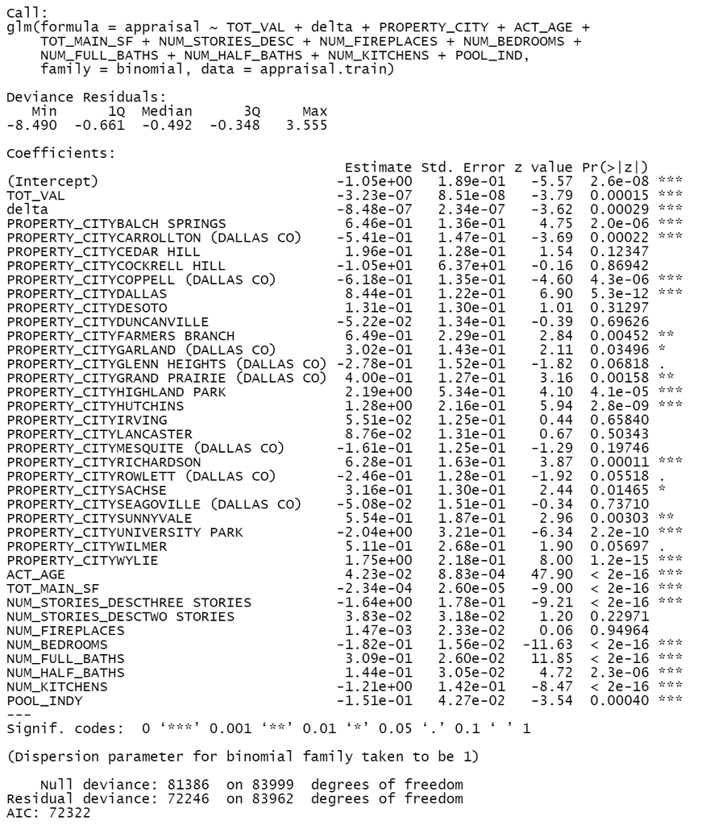

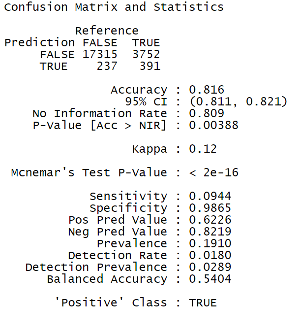

## K-Nearest Neighbor - KNN

### Building dataset

```r
appraisal.knn.vars<-(c("TOT_VAL",'PREV_MKT_VAL','delta','ACT_AGE','TOT_MAIN_SF','NUM_FIREPLACES',
                                'NUM_BEDROOMS','NUM_FULL_BATHS','NUM_HALF_BATHS','NUM_KITCHENS'))

# Set into matrix, get target labels
train.knn <- as.matrix(appraisal.train[,appraisal.knn.vars])
test.knn <- as.matrix(appraisal.test[,appraisal.knn.vars])
train.appraisal <- appraisal.train$appraisal
```

### Models

```r
set.seed(6323)

# Run KNN
# k=1
appraisal.k1pred <- knn(train.knn, test.knn, train.appraisal, k=1)
confusionMatrix(data = appraisal.k1pred, appraisal.test$appraisal,positive="TRUE")

# k=5
appraisal.k3pred <- knn(train.knn, test.knn, train.appraisal, k=3)
confusionMatrix(data = appraisal.k3pred, appraisal.test$appraisal,positive="TRUE")

# k=10
appraisal.k10pred <- knn(train.knn, test.knn, train.appraisal, k=10)
confusionMatrix(data = appraisal.k10pred, appraisal.test$appraisal,positive="TRUE")
```

### Results

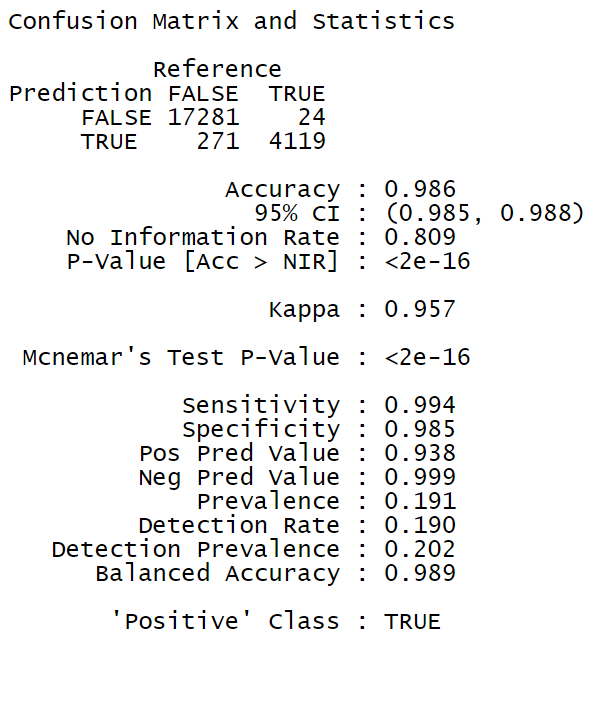

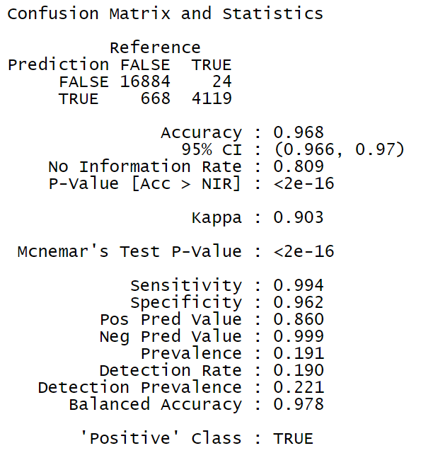

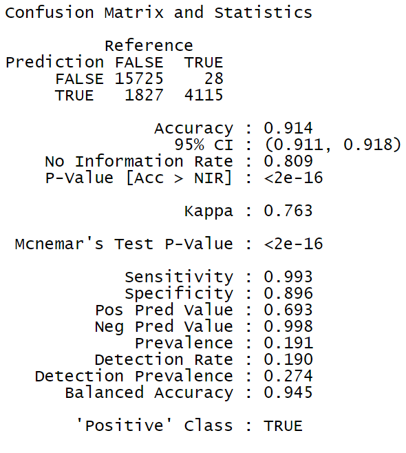

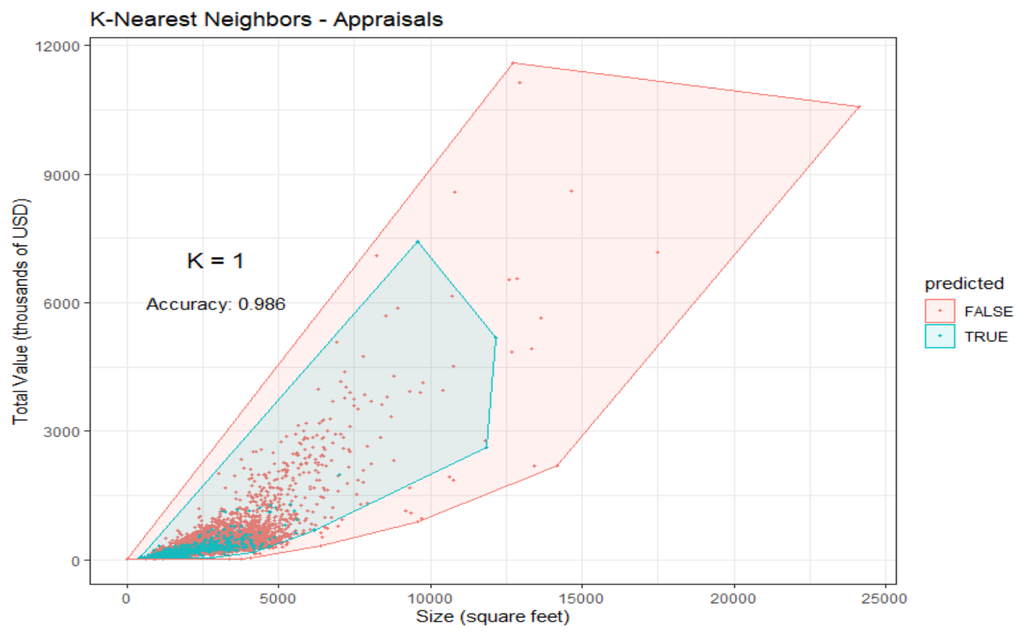

```r
#Highest Accuracy rate in KNN is acheived with k=1, save for later.
confusion_knn <- confusionMatrix(data = appraisal.k1pred, appraisal.test$appraisal,positive="TRUE")

# find decision boundary for k=1
k1pred.df1 = data.frame(test.knn, predicted = appraisal.k1pred)

k1pred.df1h = data.frame(x = k1pred.df1$TOT_MAIN_SF,
                      y = k1pred.df1$TOT_VAL/1000,
                      predicted = k1pred.df1$predicted)

k1_find_hull1 = function(df) df[chull(df$x, df$y), ]
k1_boundary1 = ddply(k1pred.df1h, .variables = "predicted", .fun = k1_find_hull1)

k1pcf1<-confusionMatrix(data=factor(k1pred.df1$predicted), as.factor(appraisal.test$appraisal), positive = 'TRUE')
k1pcf1_acc<-k1pcf1$overall["Accuracy"]

# and graph
ggplot(k1pred.df1, aes(TOT_MAIN_SF, TOT_VAL/1000, color = predicted, fill = predicted)) +
  geom_point(size = 1, pch=20) +
  geom_polygon(data = k1_boundary1, aes(x,y), alpha = 0.10)+
  ylab("Total Value (thousands of USD)")+
  xlab("Size (square feet)")+
  ggtitle("K-Nearest Neighbors - Appraisals")+
  annotate("text", x=3000, y=7000, label= "K = 1", size=5)+
  annotate("text", label = paste("Accuracy:",round(k1pcf1_acc,3)), x=3000, y=6000)+
  theme_bw()
```

## Linear Discriminant Analysis - LDA

### Model

```r
fit.lda <- lda(appraisal ~ TOT_VAL + delta + PROPERTY_CITY + ACT_AGE + TOT_MAIN_SF + NUM_STORIES_DESC + NUM_FIREPLACES + NUM_BEDROOMS + NUM_FULL_BATHS + NUM_HALF_BATHS + NUM_KITCHENS + POOL_IND , data=appraisal.train, family = binomial)
```

### Results

```r
appraisal.ldapred <- predict(fit.lda, appraisal.test)

# confusion matrix and store result
confusionMatrix(data = appraisal.ldapred$class, appraisal.test$appraisal, positive = "TRUE")
confusion_lda <- confusionMatrix(data = appraisal.ldapred$class, appraisal.test$appraisal, positive = "TRUE")
```

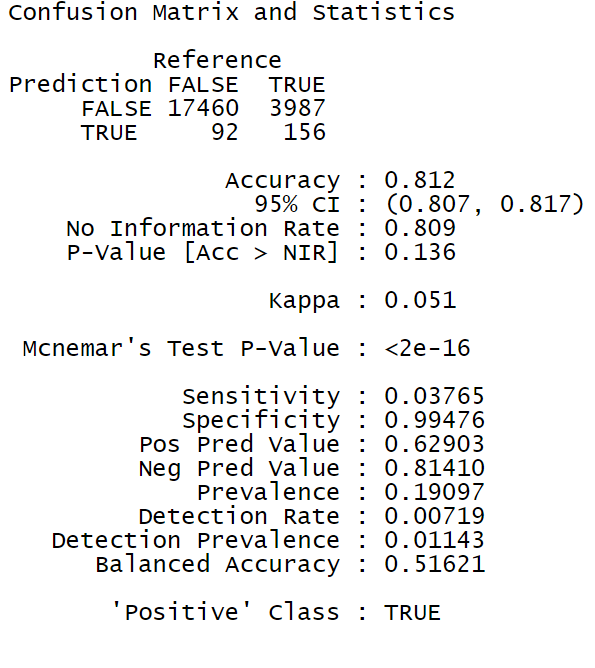

## Random Forest Analysis

### Model

```r
rf <-randomForest(appraisal ~ TOT_VAL + delta + PROPERTY_CITY + ACT_AGE + TOT_MAIN_SF + NUM_STORIES_DESC + NUM_FIREPLACES + NUM_BEDROOMS + NUM_FULL_BATHS + NUM_HALF_BATHS + NUM_KITCHENS + POOL_IND , data=appraisal.train,mtry=2,ntree=50)
```

### Results

```r
predictrf <- predict(rf,appraisal.test,type="response")

# confusion matrix and store result
confusion_forest <- confusionMatrix(data =appraisal.test$appraisal, predictrf)
confusion_forest
```

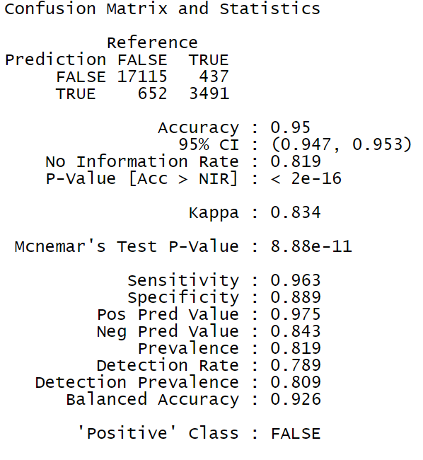

### Variable Importance

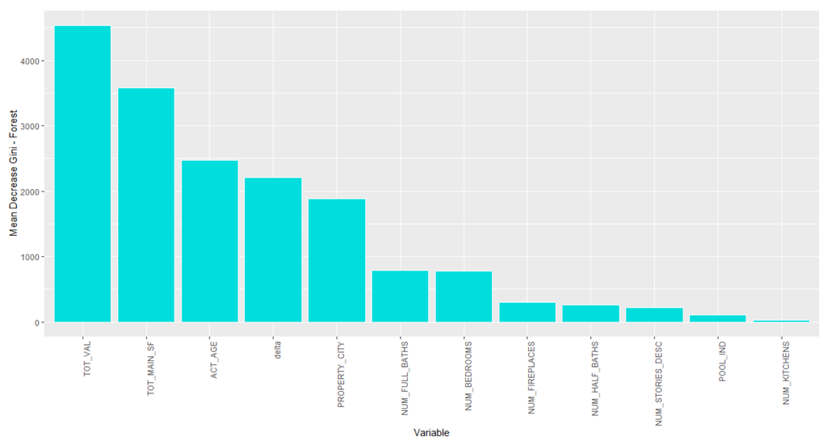

```r
# variable importance for random forest, ranked
importance <- as.data.frame(as.table(importance(rf)))
importance <- arrange(importance,-Freq)

# ordered plot for importance
forest_gini <- importance %>%  ggplot()+
  geom_col(mapping=aes(x=reorder(Var1,-Freq),y=Freq),
           fill="#00DDDD",color="white")+
  ylab("Mean Decrease Gini - Forest")+xlab("Variable")+
  theme(axis.text.x = element_text(angle = 90, hjust = 1))

# plot
forest_gini
```

# Results and discussion

## Results

| Model | Accuracy |
| --- | --- |
| Logistic | 0.816 |
| KNN (k=1) | 0.986 |
| KNN (k=3) | 0.968 |
| KNN (k=10) | 0.914 |
| LDA | 0.812 |
| Random Forest | 0.950 |

## Discussion

Generally speaking, all of the appraisal models built have very high accuracy. However, given our dataset is still so strongly skewed (1:5 | True:False), our default rate by assigned all observations to the majority class is 80%, which means that our LDA and Logistic models performed significantly worse than previously thought.

In addition, it is clear in certain models that our oversampling has damaged the integrity of the model, even though it may reduce the domination of the majority class in predictions.

This would show up specificallyin our KNN models with resampled points existing in both the training and test data set essentially giving free answers to our model. In addition, a QDA classifier was unable to run given the type and scale of resampling technique implemented.

Given this, the Random Forest model currently provides the most accurate model when factoring in generalizability.

Overall, the data provided proved more difficult to work with than expected, which had significant effects on my ability to build accurate models. Some difficulties included:

- many data points were incorrectly coded,
- many were NA or placeholder values, and
- a majority of the data proved to be rollover observations, i.e. appraisals that are renewed automatically by the DCAD.

## Next Steps

Next steps include:

- implement different(synthetic) oversampling techniques
- try undersampling the majority class
- complete model tuning